# complex-maze

Allison Davis

February 15, 2020

## Data collection

```r
library(curl)

raw <- curl("https://raw.githubusercontent.com/allisondavis/complex_maze/master/adavis_complex-complete.csv")

raw <- read.csv(raw, header = TRUE, sep = ",", stringsAsFactors = TRUE)

head(raw)
```

```
##   X.U.FEFF.NAME  SPP T1.C T1.I T2.C T2.I T3.C T3.I T1.TIME T2.TIME T3.TIME
## 1       Cypress  lat   13    8   11    5   NA   NA   607.0   411.3      NA
## 2         Amara  lat   29   23   21   15   14    8   539.2   303.5   484.6
## 3         Piper  lat   10    4   11    5   14    8   941.9   396.5   448.6
## 4         Sadie  lat   22   16    9    3   20   14   889.0   279.4   328.6
## 5          Tory form   NA   NA   22   18   15    9      NA   469.9   338.2
## 6          Aria form   32   26    8    2   13    7  1041.9   217.1   452.1
##   CONDITION
## 1    w/food
## 2    w/food
## 3    w/food
## 4    w/food
## 5    w/food
## 6    w/food
```

## Analyses

### First look

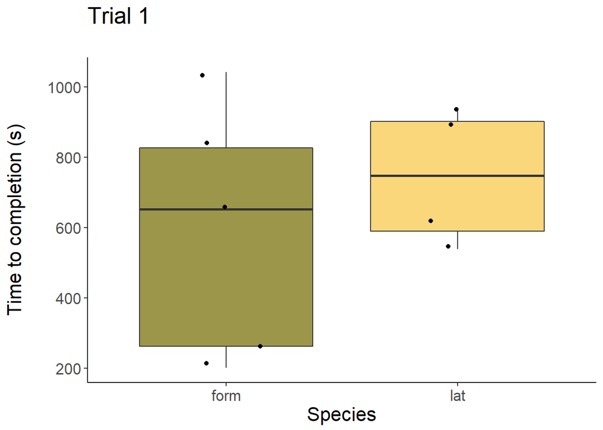

```r
library(ggplot2)

ggplot(raw, aes(x=SPP, y=T1.TIME, fill=SPP)) + geom_boxplot() + xlab("Species") + ylab("Time to completion (s)\n") + ggtitle("Trial 1\n") + geom_jitter(shape=16, position=position_jitter(0.2)) + theme_classic() + scale_fill_manual(values = c("#9C964A", "#FAD77B")) + theme(text = element_text(size = 16)) + theme(legend.position = "none")
```

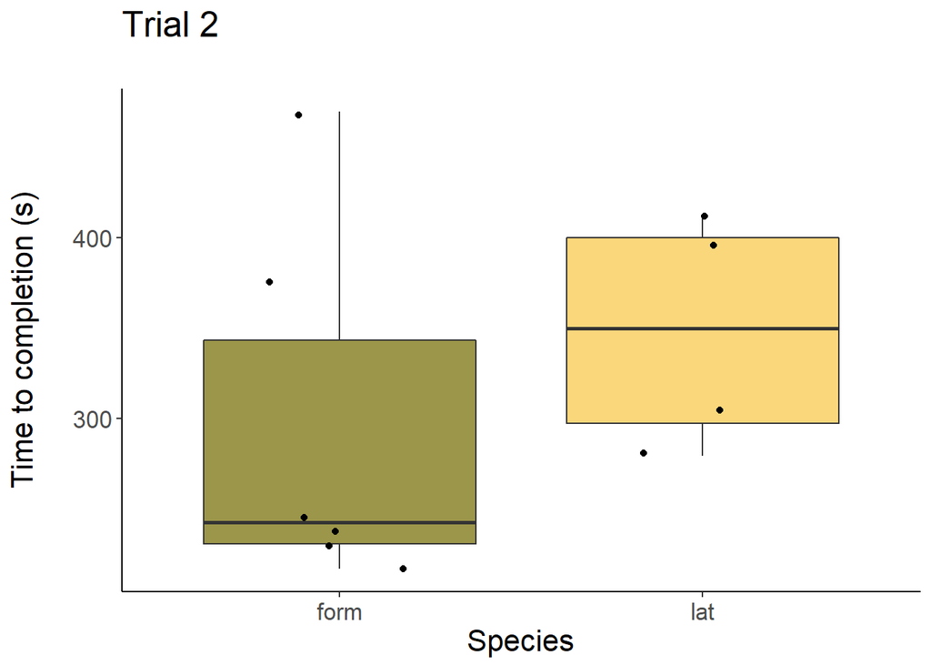

```r
ggplot(raw, aes(x=SPP, y=T2.TIME, fill=SPP)) + geom_boxplot() + xlab("Species") + ylab("Time to completion (s)\n") + ggtitle("Trial 2\n") + geom_jitter(shape=16, position=position_jitter(0.2)) + theme_classic() + scale_fill_manual(values = c("#9C964A", "#FAD77B")) + theme(text = element_text(size = 16)) + theme(legend.position = "none")
```

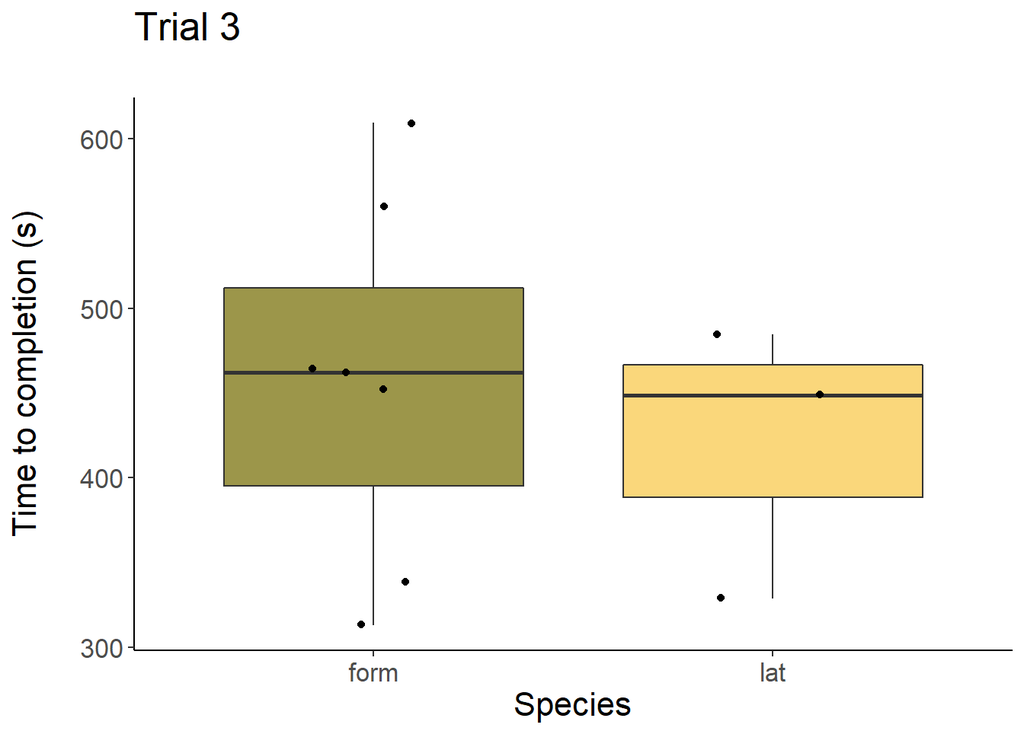

```r
ggplot(raw, aes(x=SPP, y=T3.TIME, fill=SPP)) + geom_boxplot() + xlab("Species") + ylab("Time to completion (s)\n") + ggtitle("Trial 3\n") + geom_jitter(shape=16, position=position_jitter(0.2)) + theme_classic() + scale_fill_manual(values = c("#9C964A", "#FAD77B")) + theme(text = element_text(size = 16)) + theme(legend.position = "none")
```

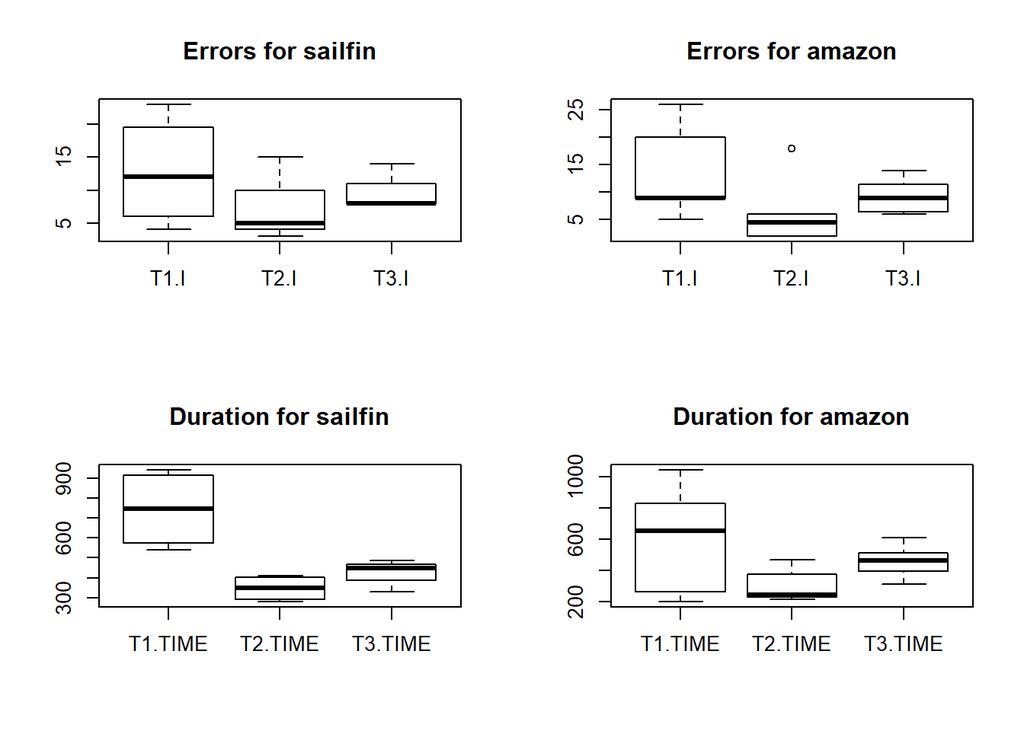

```r
#come back and get bar chart/boxplot/scatterplot to compare three trials within each spp

lat <- raw[raw$SPP == "lat",]
form <- raw[raw$SPP == "form",]

trial.er.lat <- lat[c(4,6,8)]
trial.tm.lat <- lat[9:11]

trial.er.form <- form[c(4,6,8)]
trial.tm.form <- form[c(9:11)]

par(mfrow=c(2,2))
boxplot(trial.er.lat, main="Errors for sailfin")
boxplot(trial.er.form, main="Errors for amazon")
boxplot(trial.tm.lat, main="Duration for sailfin")
boxplot(trial.tm.form, main ="Duration for amazon")
```

### Simple stats

- using t-test to detect differences in means between species in same trial, and between trials in same species

```r
#testing differences between species w/in same trial
t.test(lat$T1.I, form$T1.I, alternative = "two.sided")
```

```
##
##  Welch Two Sample t-test
##
## data:  lat$T1.I and form$T1.I
## t = -0.18159, df = 6.6893, p-value = 0.8613
## alternative hypothesis: true difference in means is not equal to 0
## 95 percent confidence interval:
##  -14.85295  12.75295
## sample estimates:
## mean of x mean of y
##     12.75     13.80
```

```r
t.test(lat$T2.I, form$T2.I, alternative = "two.sided")
```

```
##
##  Welch Two Sample t-test
##
## data:  lat$T2.I and form$T2.I
## t = 0.22798, df = 7.0861, p-value = 0.8261
## alternative hypothesis: true difference in means is not equal to 0
## 95 percent confidence interval:
##  -7.788789  9.455456
## sample estimates:
## mean of x mean of y
##  7.000000  6.166667
```

```r
t.test(lat$T3.I, form$T3.I, alternative = "two.sided")
```

```
##
##  Welch Two Sample t-test
##
## data:  lat$T3.I and form$T3.I
## t = 0.29916, df = 3.8314, p-value = 0.7803
## alternative hypothesis: true difference in means is not equal to 0
## 95 percent confidence interval:
##  -6.031459  7.460031
## sample estimates:
## mean of x mean of y
## 10.000000  9.285714
```

```r
#testing differences between trials w/in same species
t.test(lat$T1.I, lat$T2.I, alternative = "two.sided")
```

```
##
##  Welch Two Sample t-test
##
## data:  lat$T1.I and lat$T2.I
## t = 1.1448, df = 5.1052, p-value = 0.3031
## alternative hypothesis: true difference in means is not equal to 0
## 95 percent confidence interval:
##  -7.082086 18.582086
## sample estimates:
## mean of x mean of y
##     12.75      7.00
```

```r
t.test(lat$T1.I, lat$T3.I, alternative = "two.sided")
```

```
##
##  Welch Two Sample t-test
##
## data:  lat$T1.I and lat$T3.I
## t = 0.58769, df = 4.1779, p-value = 0.587
## alternative hypothesis: true difference in means is not equal to 0
## 95 percent confidence interval:
##  -10.02654  15.52654
## sample estimates:
## mean of x mean of y
##     12.75     10.00
```

```r
t.test(lat$T2.I, lat$T3.I, alternative = "two.sided")
```

```
##
##  Welch Two Sample t-test
##
## data:  lat$T2.I and lat$T3.I
## t = -0.89113, df = 4.9543, p-value = 0.414
## alternative hypothesis: true difference in means is not equal to 0
## 95 percent confidence interval:
##  -11.677941   5.677941
## sample estimates:
## mean of x mean of y
##         7        10
```

```r
t.test(form$T1.I, form$T2.I, alternative = "two.sided")
```

```
##
##  Welch Two Sample t-test
##
## data:  form$T1.I and form$T2.I
## t = 1.6437, df = 6.8772, p-value = 0.145
## alternative hypothesis: true difference in means is not equal to 0
## 95 percent confidence interval:
##  -3.388137 18.654803
## sample estimates:
## mean of x mean of y
## 13.800000  6.166667
```

```r
t.test(form$T1.I, form$T3.I, alternative = "two.sided")
```

```
##
##  Welch Two Sample t-test
##
## data:  form$T1.I and form$T3.I
## t = 1.0872, df = 4.8844, p-value = 0.3277
## alternative hypothesis: true difference in means is not equal to 0
## 95 percent confidence interval:
##  -6.235675 15.264246
## sample estimates:
## mean of x mean of y
## 13.800000  9.285714
```

```r
t.test(form$T2.I, form$T3.I, alternative = "two.sided")
```

```
##
##  Welch Two Sample t-test
##
## data:  form$T2.I and form$T3.I
## t = -1.122, df = 7.7081, p-value = 0.2956
## alternative hypothesis: true difference in means is not equal to 0
## 95 percent confidence interval:
##  -9.572268  3.334173
## sample estimates:
## mean of x mean of y
##  6.166667  9.285714
```

No significant differences found.

- using F-test to detect different variations in different species in same trial, and different trials in same species

```r
#testing variances between species w/in same trial
var.test(lat$T1.I, form$T1.I, alternative = "two.sided")
```

```
##
##  F test to compare two variances
##
## data:  lat$T1.I and form$T1.I
## F = 0.92128, num df = 3, denom df = 4, p-value = 0.9858
## alternative hypothesis: true ratio of variances is not equal to 1
## 95 percent confidence interval:
##   0.09231988 13.91220603
## sample estimates:
## ratio of variances
##          0.9212784
```

```r
var.test(lat$T2.I, form$T2.I, alternative = "two.sided")
```

```
##
##  F test to compare two variances
##
## data:  lat$T2.I and form$T2.I
## F = 0.81106, num df = 3, denom df = 5, p-value = 0.92
## alternative hypothesis: true ratio of variances is not equal to 1
## 95 percent confidence interval:
##   0.1044697 12.0724831
## sample estimates:
## ratio of variances
##          0.8110599
```

```r
var.test(lat$T3.I, form$T3.I, alternative = "two.sided")
```

```
##
##  F test to compare two variances
##
## data:  lat$T3.I and form$T3.I
## F = 1.008, num df = 2, denom df = 6, p-value = 0.8387
## alternative hypothesis: true ratio of variances is not equal to 1
## 95 percent confidence interval:
##   0.1388457 39.6461096
## sample estimates:
## ratio of variances
##              1.008
```

```r
#testing variances between trials w/in same species
var.test(lat$T1.I, lat$T2.I, alternative = "two.sided")
```

```
##
##  F test to compare two variances
##
## data:  lat$T1.I and lat$T2.I
## F = 2.4403, num df = 3, denom df = 3, p-value = 0.483
## alternative hypothesis: true ratio of variances is not equal to 1
## 95 percent confidence interval:
##   0.1580615 37.6768684
## sample estimates:
## ratio of variances
##           2.440341
```

```r
var.test(lat$T1.I, lat$T3.I, alternative = "two.sided")
```

```
##
##  F test to compare two variances
##
## data:  lat$T1.I and lat$T3.I
## F = 5.9653, num df = 3, denom df = 2, p-value = 0.2939
## alternative hypothesis: true ratio of variances is not equal to 1
## 95 percent confidence interval:
##   0.1523095 95.7075515
## sample estimates:
## ratio of variances
##           5.965278
```

```r
var.test(lat$T2.I, lat$T3.I, alternative = "two.sided")
```

```
##
##  F test to compare two variances
##
## data:  lat$T2.I and lat$T3.I
## F = 2.4444, num df = 3, denom df = 2, p-value = 0.6071
## alternative hypothesis: true ratio of variances is not equal to 1
## 95 percent confidence interval:
##   0.06241322 39.21892683
## sample estimates:
## ratio of variances
##           2.444444
```

```r
var.test(form$T1.I, form$T2.I, alternative = "two.sided")
```

```
##
##  F test to compare two variances
##
## data:  form$T1.I and form$T2.I
## F = 2.1484, num df = 4, denom df = 5, p-value = 0.4235
## alternative hypothesis: true ratio of variances is not equal to 1
## 95 percent confidence interval:
##   0.2907986 20.1185083
## sample estimates:
## ratio of variances
##           2.148387
```

```r
var.test(form$T1.I, form$T3.I, alternative = "two.sided")
```

```
##
##  F test to compare two variances
##
## data:  form$T1.I and form$T3.I
## F = 6.5268, num df = 4, denom df = 6, p-value = 0.04489
## alternative hypothesis: true ratio of variances is not equal to 1
## 95 percent confidence interval:
##   1.048118 60.029010
## sample estimates:
## ratio of variances
##             6.5268
```

```r
var.test(form$T2.I, form$T3.I, alternative = "two.sided")
```

```
##
##  F test to compare two variances
##
## data:  form$T2.I and form$T3.I
## F = 3.038, num df = 5, denom df = 6, p-value = 0.2087
## alternative hypothesis: true ratio of variances is not equal to 1
## 95 percent confidence interval:
##   0.5073849 21.1982582
## sample estimates:
## ratio of variances
##              3.038
```

- *will repeat for time of trials*
- using t-test to detect differences in means between species in same trial, and between trials in same species

```r
#testing differences between species w/in same trial
t.test(lat$T1.TIME, form$T1.TIME, alternative = "two.sided")
```

```
##
##  Welch Two Sample t-test
##
## data:  lat$T1.TIME and form$T1.TIME
## t = 0.77604, df = 6.4069, p-value = 0.4654
## alternative hypothesis: true difference in means is not equal to 0
## 95 percent confidence interval:
##  -311.0089  606.4789
## sample estimates:
## mean of x mean of y
##   744.275   596.540
```

```r
t.test(lat$T2.TIME, form$T2.TIME, alternative = "two.sided")
```

```
##
##  Welch Two Sample t-test
##
## data:  lat$T2.TIME and form$T2.TIME
## t = 0.96631, df = 7.9991, p-value = 0.3622
## alternative hypothesis: true difference in means is not equal to 0
## 95 percent confidence interval:
##  -71.64431 174.99431
## sample estimates:
## mean of x mean of y
##   347.675   296.000
```

```r
t.test(lat$T3.TIME, form$T3.TIME, alternative = "two.sided")
```

```
##
##  Welch Two Sample t-test
##
## data:  lat$T3.TIME and form$T3.TIME
## t = -0.58417, df = 5.1063, p-value = 0.584
## alternative hypothesis: true difference in means is not equal to 0
## 95 percent confidence interval:
##  -195.04  122.44
## sample estimates:
## mean of x mean of y
##     420.6     456.9
```

```r
#testing differences between trials w/in same species
t.test(lat$T1.TIME, lat$T2.TIME, alternative = "two.sided")
```

```
##
##  Welch Two Sample t-test
##
## data:  lat$T1.TIME and lat$T2.TIME
## t = 3.7539, df = 3.6399, p-value = 0.02354
## alternative hypothesis: true difference in means is not equal to 0
## 95 percent confidence interval:
##   91.45945 701.74055
## sample estimates:
## mean of x mean of y
##   744.275   347.675
```

```r
t.test(lat$T1.TIME, lat$T3.TIME, alternative = "two.sided")
```

```
##
##  Welch Two Sample t-test
##
## data:  lat$T1.TIME and lat$T3.TIME
## t = 2.9186, df = 4.1661, p-value = 0.04121
## alternative hypothesis: true difference in means is not equal to 0
## 95 percent confidence interval:
##   20.54608 626.80392
## sample estimates:
## mean of x mean of y
##   744.275   420.600
```

```r
t.test(lat$T2.TIME, lat$T3.TIME, alternative = "two.sided")
```

```
##
##  Welch Two Sample t-test
##
## data:  lat$T2.TIME and lat$T3.TIME
## t = -1.2673, df = 3.8239, p-value = 0.2767
## alternative hypothesis: true difference in means is not equal to 0
## 95 percent confidence interval:
##  -235.6303   89.7803
## sample estimates:
## mean of x mean of y
##   347.675   420.600
```

```r
t.test(form$T1.TIME, form$T2.TIME, alternative = "two.sided")
```

```
##
##  Welch Two Sample t-test
##
## data:  form$T1.TIME and form$T2.TIME
## t = 1.798, df = 4.5436, p-value = 0.1379
## alternative hypothesis: true difference in means is not equal to 0
## 95 percent confidence interval:
##  -142.4406  743.5206
## sample estimates:
## mean of x mean of y
##    596.54    296.00
```

```r
t.test(form$T1.TIME, form$T3.TIME, alternative = "two.sided")
```

```
##
##  Welch Two Sample t-test
##
## data:  form$T1.TIME and form$T3.TIME
## t = 0.83745, df = 4.5045, p-value = 0.4445
## alternative hypothesis: true difference in means is not equal to 0
## 95 percent confidence interval:
##  -303.5658  582.8458
## sample estimates:
## mean of x mean of y
##    596.54    456.90
```

```r
t.test(form$T2.TIME, form$T3.TIME, alternative = "two.sided")
```

```
##
##  Welch Two Sample t-test
##
## data:  form$T2.TIME and form$T3.TIME
## t = -2.7554, df = 10.814, p-value = 0.01898
## alternative hypothesis: true difference in means is not equal to 0
## 95 percent confidence interval:
##  -289.69706  -32.10294
## sample estimates:
## mean of x mean of y
##     296.0     456.9
```

- using F-test to detect different variations in different species in same trial, and different trials in same species

```r
#testing variances between species w/in same trial
var.test(lat$T1.TIME, form$T1.TIME, alternative = "two.sided")
```

```
##
##  F test to compare two variances
##
## data:  lat$T1.TIME and form$T1.TIME
## F = 0.30803, num df = 3, denom df = 4, p-value = 0.3607
## alternative hypothesis: true ratio of variances is not equal to 1
## 95 percent confidence interval:
##  0.03086767 4.65162392
## sample estimates:
## ratio of variances
##          0.3080346
```

```r
var.test(lat$T2.TIME, form$T2.TIME, alternative = "two.sided")
```

```
##
##  F test to compare two variances
##
## data:  lat$T2.TIME and form$T2.TIME
## F = 0.40883, num df = 3, denom df = 5, p-value = 0.4922
## alternative hypothesis: true ratio of variances is not equal to 1
## 95 percent confidence interval:
##  0.05266025 6.08540082
## sample estimates:
## ratio of variances
##          0.4088326
```

```r
var.test(lat$T3.TIME, form$T3.TIME, alternative = "two.sided")
```

```
##
##  F test to compare two variances
##
## data:  lat$T3.TIME and form$T3.TIME
## F = 0.58213, num df = 2, denom df = 6, p-value = 0.8252
## alternative hypothesis: true ratio of variances is not equal to 1
## 95 percent confidence interval:
##   0.08018449 22.89593658
## sample estimates:
## ratio of variances
##          0.5821278
```

```r
#testing variances between trials w/in same species
var.test(lat$T1.TIME, lat$T2.TIME, alternative = "two.sided")
```

```
##
##  F test to compare two variances
##
## data:  lat$T1.TIME and lat$T2.TIME
## F = 9.2681, num df = 3, denom df = 3, p-value = 0.1001
## alternative hypothesis: true ratio of variances is not equal to 1
## 95 percent confidence interval:
##    0.6002946 143.0912411
## sample estimates:
## ratio of variances
##           9.268058
```

```r
var.test(lat$T1.TIME, lat$T3.TIME, alternative = "two.sided")
```

```
##
##  F test to compare two variances
##
## data:  lat$T1.TIME and lat$T3.TIME
## F = 6.0402, num df = 3, denom df = 2, p-value = 0.2907
## alternative hypothesis: true ratio of variances is not equal to 1
## 95 percent confidence interval:
##   0.1542231 96.9100159
## sample estimates:
## ratio of variances
##           6.040225
```

```r
var.test(lat$T2.TIME, lat$T3.TIME, alternative = "two.sided")
```

```
##
##  F test to compare two variances
##
## data:  lat$T2.TIME and lat$T3.TIME
## F = 0.65172, num df = 3, denom df = 2, p-value = 0.6951
## alternative hypothesis: true ratio of variances is not equal to 1
## 95 percent confidence interval:
##   0.01664029 10.45634518
## sample estimates:
## ratio of variances
##           0.651725
```

```r
var.test(form$T1.TIME, form$T2.TIME, alternative = "two.sided")
```

```
##
##  F test to compare two variances
##
## data:  form$T1.TIME and form$T2.TIME
## F = 12.301, num df = 4, denom df = 5, p-value = 0.0169
## alternative hypothesis: true ratio of variances is not equal to 1
## 95 percent confidence interval:
##    1.665001 115.190859
## sample estimates:
## ratio of variances
##           12.30084
```

```r
var.test(form$T1.TIME, form$T3.TIME, alternative = "two.sided")
```

```
##
##  F test to compare two variances
##
## data:  form$T1.TIME and form$T3.TIME
## F = 11.415, num df = 4, denom df = 6, p-value = 0.01144
## alternative hypothesis: true ratio of variances is not equal to 1
## 95 percent confidence interval:
##    1.833082 104.986361
## sample estimates:
## ratio of variances
##            11.4149
```

```r
var.test(form$T2.TIME, form$T3.TIME, alternative = "two.sided")
```

```
##
##  F test to compare two variances
##
## data:  form$T2.TIME and form$T3.TIME
## F = 0.92798, num df = 5, denom df = 6, p-value = 0.9547
## alternative hypothesis: true ratio of variances is not equal to 1
## 95 percent confidence interval:
##  0.154984 6.475147
## sample estimates:
## ratio of variances
##           0.927977
```

### Complex stats

#### **First try**

Here I will use a generalized linear mixed-effects model to assess differences in the number of errors made across trials between the species. * species as fixed effect, individual ID as random effect, and trial number as covariate

Had to rearrange the data, so that each trial for each individual was on a separate line. Will upload now.

```r
library(curl)

Mraw <- curl("https://raw.githubusercontent.com/allisondavis/complex_maze/master/mixed.format_complex-raw.csv")

Mraw <- read.csv(Mraw, header = TRUE, sep = ",", stringsAsFactors = TRUE)

head(Mraw)
```

```
##   X.U.FEFF.NAME SPP TRIAL INC  TIME CONDITION
## 1       Cypress lat     1   8 607.0    w/food
## 2       Cypress lat     2   5 411.3    w/food
## 3       Cypress lat     3  NA    NA    w/food
## 4         Amara lat     1  23 539.2    w/food
## 5         Amara lat     2  15 303.5    w/food
## 6         Amara lat     3   8 484.6    w/food
```

Now let’s check how the data are distributed. Normal distributions can use linear mixed models, whereas non-normal distributions can use generalized linear mixed models.

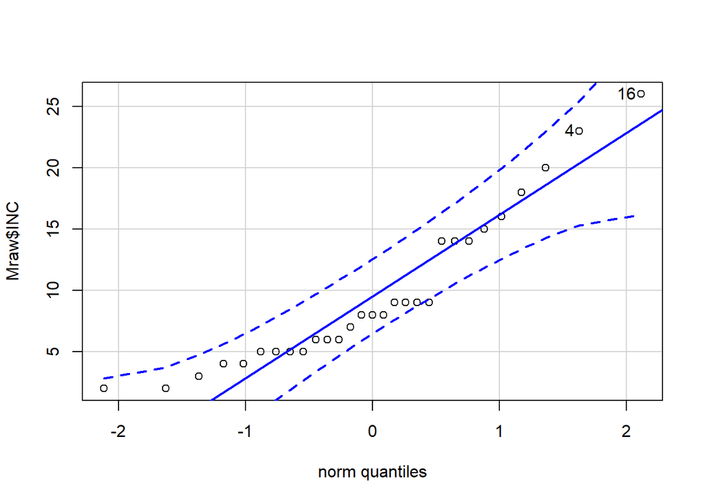

```
## [1] 16  4
```

```r
library(car)

qqp(Mraw$INC, "norm")  #fits normal fine, so can used LMM
```

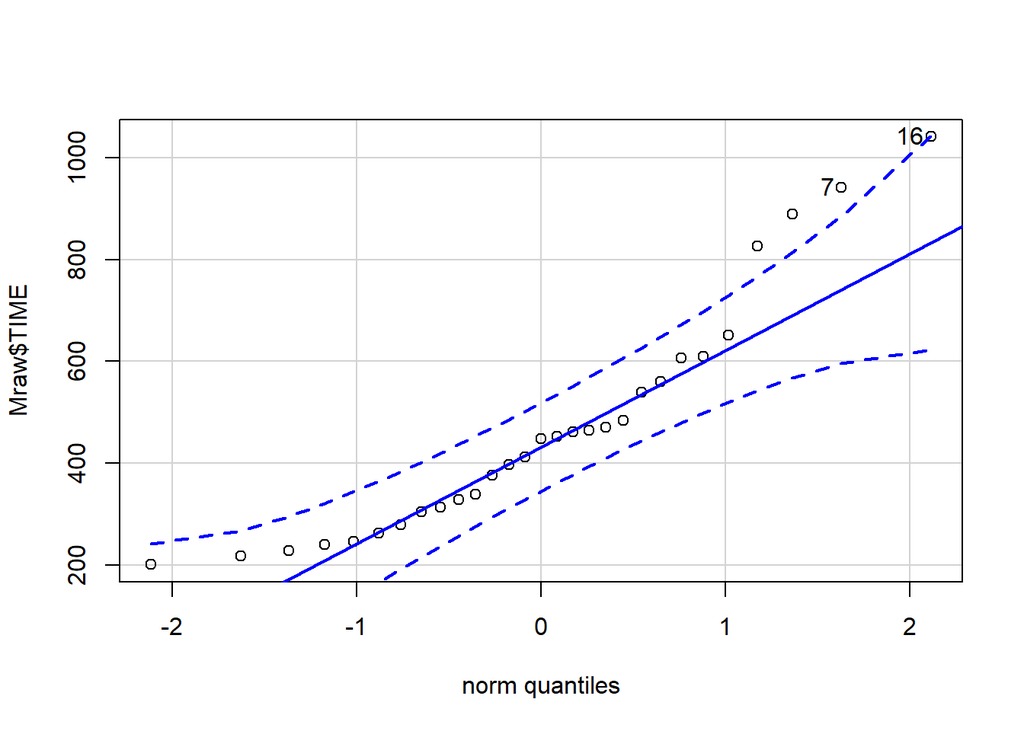

```
## [1] 16  7
```

```r
qqp(Mraw$TIME, "norm") #fits ok, little off in top right; can try LMM but may want to try a different distribution
```

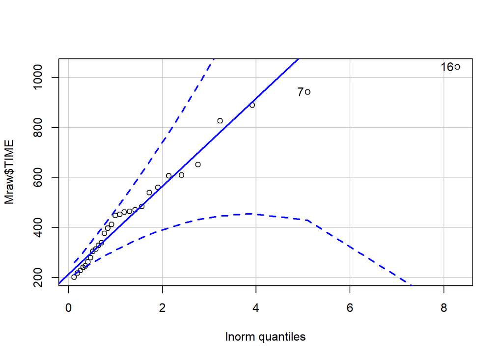

```
## [1] 16  7
```

```r
qqp(Mraw$TIME, "lnorm") #fits better, since no points are outside dashed lines; try out GLMM
```

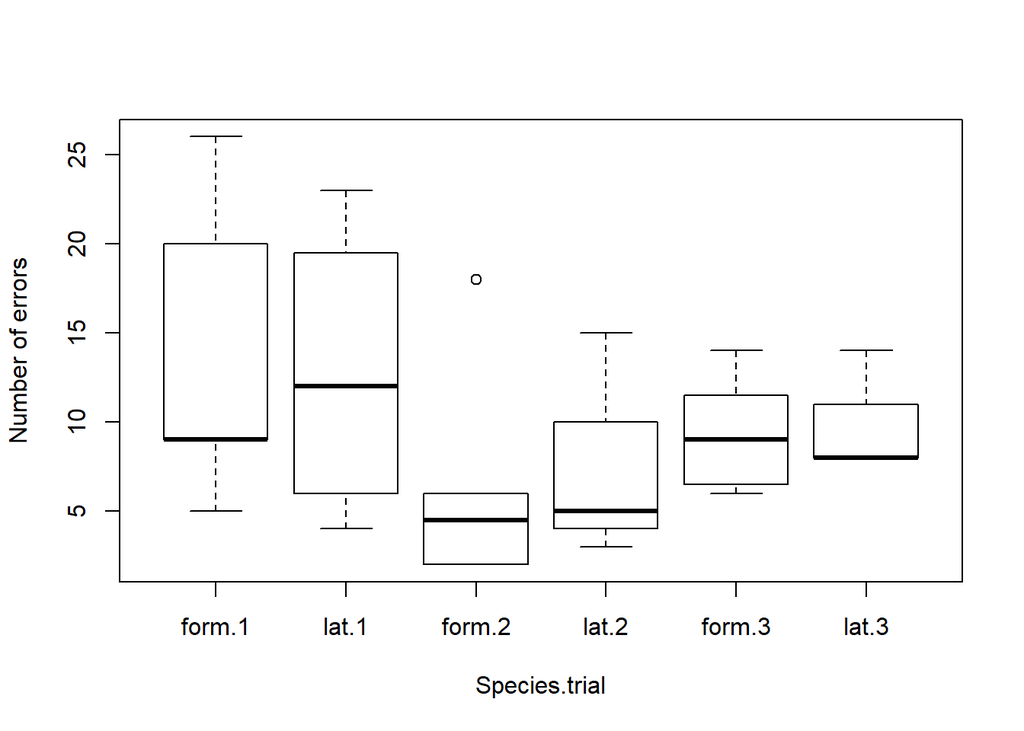

```r
boxplot(data=Mraw, INC ~ SPP * TRIAL, xlab= "Species.trial", ylab= "Number of errors")
```

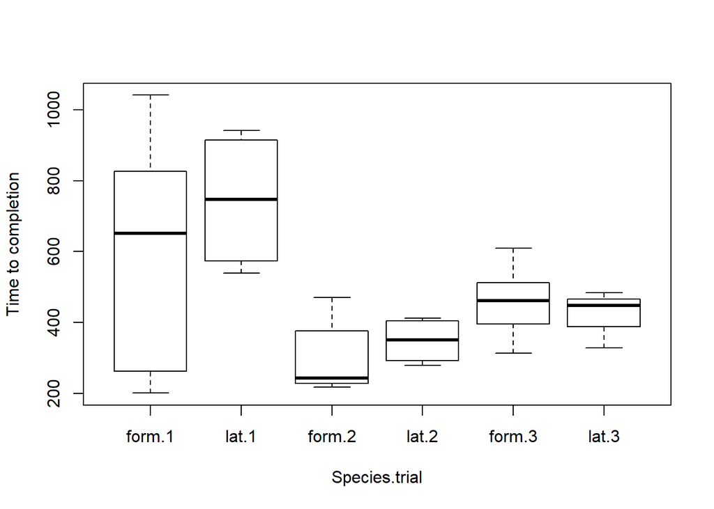

```r
boxplot(data=Mraw, TIME ~ SPP * TRIAL, xlab= "Species.trial", ylab= "Time to completion")
```

Now to the mixed models.

```r
library(lme4)
library(lmerTest)
library(car)


m1 <- lmer(INC ~ TRIAL * SPP + (1|X.U.FEFF.NAME), data = Mraw)
summary(m1)
```

```
## Linear mixed model fit by REML. t-tests use Satterthwaite's method [
## lmerModLmerTest]
## Formula: INC ~ TRIAL * SPP + (1 | X.U.FEFF.NAME)
##    Data: Mraw
##
## REML criterion at convergence: 174.1
##
## Scaled residuals:
##     Min      1Q  Median      3Q     Max
## -1.1892 -0.7340 -0.2719  0.8070  2.2084
##
## Random effects:
##  Groups        Name        Variance Std.Dev.
##  X.U.FEFF.NAME (Intercept)  0.00    0.000
##  Residual                  42.11    6.489
## Number of obs: 29, groups:  X.U.FEFF.NAME, 11
##
## Fixed effects:
##              Estimate Std. Error      df t value Pr(>|t|)
## (Intercept)   13.6226     4.2747 25.0000   3.187  0.00384 **
## TRIAL         -1.9528     1.8908 25.0000  -1.033  0.31159
## SPPlat        -0.6490     6.6568 25.0000  -0.097  0.92312
## TRIAL:SPPlat   0.3476     3.1096 25.0000   0.112  0.91190
## ---
## Signif. codes:  0 '***' 0.001 '**' 0.01 '*' 0.05 '.' 0.1 ' ' 1
##
## Correlation of Fixed Effects:
##             (Intr) TRIAL  SPPlat
## TRIAL       -0.934
## SPPlat      -0.642  0.600
## TRIAL:SPPlt  0.568 -0.608 -0.927
## convergence code: 0
## boundary (singular) fit: see ?isSingular
```

```r
Anova(m1, type = 3)
```

```
## Analysis of Deviance Table (Type III Wald chisquare tests)
##
## Response: INC
##               Chisq Df Pr(>Chisq)
## (Intercept) 10.1557  1   0.001439 **
## TRIAL        1.0667  1   0.301698
## SPP          0.0095  1   0.922339
## TRIAL:SPP    0.0125  1   0.911004
## ---
## Signif. codes:  0 '***' 0.001 '**' 0.01 '*' 0.05 '.' 0.1 ' ' 1
```

```r
Anova(m1, type=3, test.statistic = "F")
```

```
## Analysis of Deviance Table (Type III Wald F tests with Kenward-Roger df)
##
## Response: INC
##                  F Df Df.res   Pr(>F)
## (Intercept) 9.7497  1 22.740 0.004829 **
## TRIAL       1.0362  1 18.103 0.322129
## SPP         0.0093  1 22.300 0.924097
## TRIAL:SPP   0.0122  1 17.979 0.913417
## ---
## Signif. codes:  0 '***' 0.001 '**' 0.01 '*' 0.05 '.' 0.1 ' ' 1
```

```r
m2 <- lmer(TIME~TRIAL*SPP + (1|X.U.FEFF.NAME), data = Mraw)
summary(m2)
```

```
## Linear mixed model fit by REML. t-tests use Satterthwaite's method [
## lmerModLmerTest]
## Formula: TIME ~ TRIAL * SPP + (1 | X.U.FEFF.NAME)
##    Data: Mraw
##
## REML criterion at convergence: 348.9
##
## Scaled residuals:
##     Min      1Q  Median      3Q     Max
## -1.4248 -0.9001 -0.2498  0.6884  2.5107
##
## Random effects:
##  Groups        Name        Variance Std.Dev.
##  X.U.FEFF.NAME (Intercept)     0      0.0
##  Residual                  45709    213.8
## Number of obs: 29, groups:  X.U.FEFF.NAME, 11
##
## Fixed effects:
##              Estimate Std. Error      df t value Pr(>|t|)
## (Intercept)    561.88     140.84   25.00   3.990 0.000509 ***
## TRIAL          -56.76      62.30   25.00  -0.911 0.370931
## SPPlat         282.45     219.32   25.00   1.288 0.209602
## TRIAL:SPPlat  -117.43     102.45   25.00  -1.146 0.262560
## ---
## Signif. codes:  0 '***' 0.001 '**' 0.01 '*' 0.05 '.' 0.1 ' ' 1
##
## Correlation of Fixed Effects:
##             (Intr) TRIAL  SPPlat
## TRIAL       -0.934
## SPPlat      -0.642  0.600
## TRIAL:SPPlt  0.568 -0.608 -0.927
## convergence code: 0
## boundary (singular) fit: see ?isSingular
```

```r
Anova(m2, type = 3)
```

```
## Analysis of Deviance Table (Type III Wald chisquare tests)
##
## Response: TIME
##               Chisq Df Pr(>Chisq)
## (Intercept) 15.9163  1  6.621e-05 ***
## TRIAL        0.8302  1     0.3622
## SPP          1.6585  1     0.1978
## TRIAL:SPP    1.3138  1     0.2517
## ---
## Signif. codes:  0 '***' 0.001 '**' 0.01 '*' 0.05 '.' 0.1 ' ' 1
```

```r
Anova(m2, type=3, test.statistic = "F")
```

```
## Analysis of Deviance Table (Type III Wald F tests with Kenward-Roger df)
##
## Response: TIME
##                   F Df Df.res    Pr(>F)
## (Intercept) 15.2801  1 22.740 0.0007169 ***
## TRIAL        0.8064  1 18.103 0.3809754
## SPP          1.6203  1 22.300 0.2161646
## TRIAL:SPP    1.2787  1 17.979 0.2729933
## ---
## Signif. codes:  0 '***' 0.001 '**' 0.01 '*' 0.05 '.' 0.1 ' ' 1
```

Both model fits give me a warning about singular fit. I am unsure what this means or what to do about it. Not sure if I am coding the fixed and random effects correctly (should subjects be numbers rather than names? should there be a factor instead of 1 prior to random effect?). Think I want to understand this prior to trying the GLMM.

#### **Second try**

I changed the csv file to include subject number instead of name. Additionally, I will break the model down into 3 questions.

```r
library(curl)

raw2 <- curl("https://raw.githubusercontent.com/allisondavis/complex_maze/master/mixed.format_complex-raw2.csv")

raw2 <- read.csv(raw2, header = TRUE, sep = ",", stringsAsFactors = TRUE)

raw2
```

```
##    X.U.FEFF.SUBJECT  SPP TRIAL INC   TIME CONDITION
## 1                 1  lat     1   8  607.0    w/food
## 2                 1  lat     2   5  411.3    w/food
## 3                 1  lat     3  NA     NA    w/food
## 4                 2  lat     1  23  539.2    w/food
## 5                 2  lat     2  15  303.5    w/food
## 6                 2  lat     3   8  484.6    w/food
## 7                 3  lat     1   4  941.9    w/food
## 8                 3  lat     2   5  396.5    w/food
## 9                 3  lat     3   8  448.6    w/food
## 10                4  lat     1  16  889.0    w/food
## 11                4  lat     2   3  279.4    w/food
## 12                4  lat     3  14  328.6    w/food
## 13                5 form     1  NA     NA    w/food
## 14                5 form     2  18  469.9    w/food
```

[output cut: 19 more lines]

```r
names(raw2)[1] <- "SUBJECT"   #easier to type without the X.U.FEFF in front!

raw2
```

```
##    SUBJECT  SPP TRIAL INC   TIME CONDITION
## 1        1  lat     1   8  607.0    w/food
## 2        1  lat     2   5  411.3    w/food
## 3        1  lat     3  NA     NA    w/food
## 4        2  lat     1  23  539.2    w/food
## 5        2  lat     2  15  303.5    w/food
## 6        2  lat     3   8  484.6    w/food
## 7        3  lat     1   4  941.9    w/food
## 8        3  lat     2   5  396.5    w/food
## 9        3  lat     3   8  448.6    w/food
## 10       4  lat     1  16  889.0    w/food
## 11       4  lat     2   3  279.4    w/food
## 12       4  lat     3  14  328.6    w/food
## 13       5 form     1  NA     NA    w/food
## 14       5 form     2  18  469.9    w/food
```

[output cut: 19 more lines]

- **Model 1**: How does species affect errors/duration? Fixed effects: INC or TIME, SPP; Random effects: TRIAL, SUBJECT

```r
library(lme4)
library(lmerTest)
library(car)


M1.e <- lmer(INC~SPP + (1|TRIAL)+(1|SUBJECT), data = raw2)
summary(M1.e)
```

```
## Linear mixed model fit by REML. t-tests use Satterthwaite's method [
## lmerModLmerTest]
## Formula: INC ~ SPP + (1 | TRIAL) + (1 | SUBJECT)
##    Data: raw2
##
## REML criterion at convergence: 180.8
##
## Scaled residuals:
##     Min      1Q  Median      3Q     Max
## -1.3821 -0.5835 -0.4035  0.7108  2.3371
##
## Random effects:
##  Groups   Name        Variance Std.Dev.
##  SUBJECT  (Intercept)  0.00    0.000
##  TRIAL    (Intercept)  7.84    2.800
##  Residual             35.81    5.984
## Number of obs: 29, groups:  SUBJECT, 11; TRIAL, 3
##
## Fixed effects:
##             Estimate Std. Error      df t value Pr(>|t|)
## (Intercept)   9.6402     2.1491  2.8153   4.486   0.0236 *
## SPPlat        0.2554     2.3021 25.2274   0.111   0.9126
## ---
## Signif. codes:  0 '***' 0.001 '**' 0.01 '*' 0.05 '.' 0.1 ' ' 1
##
## Correlation of Fixed Effects:
##        (Intr)
## SPPlat -0.408
## convergence code: 0
## boundary (singular) fit: see ?isSingular
```

```r
Anova(M1.e, type = 3, test.statistic = "F")
```

```
## Analysis of Deviance Table (Type III Wald F tests with Kenward-Roger df)
##
## Response: INC
##                   F Df Df.res  Pr(>F)
## (Intercept) 19.8480  1 2.6694 0.02681 *
## SPP          0.0119  1 8.2703 0.91559
## ---
## Signif. codes:  0 '***' 0.001 '**' 0.01 '*' 0.05 '.' 0.1 ' ' 1
```

```r
M1.t <- lmer(TIME~SPP + (1|TRIAL)+(1|SUBJECT), data = raw2)
summary(M1.t)
```

```
## Linear mixed model fit by REML. t-tests use Satterthwaite's method [
## lmerModLmerTest]
## Formula: TIME ~ SPP + (1 | TRIAL) + (1 | SUBJECT)
##    Data: raw2
##
## REML criterion at convergence: 367.3
##
## Scaled residuals:
##      Min       1Q   Median       3Q      Max
## -2.26954 -0.49233 -0.02431  0.35368  2.35005
##
## Random effects:
##  Groups   Name        Variance Std.Dev.
##  SUBJECT  (Intercept)     0      0.0
##  TRIAL    (Intercept) 26262    162.1
##  Residual             33174    182.1
## Number of obs: 29, groups:  SUBJECT, 11; TRIAL, 3
##
## Fixed effects:
##             Estimate Std. Error      df t value Pr(>|t|)
## (Intercept)  452.196    103.036   2.283   4.389   0.0377 *
## SPPlat        57.689     70.186  25.081   0.822   0.4188
## ---
## Signif. codes:  0 '***' 0.001 '**' 0.01 '*' 0.05 '.' 0.1 ' ' 1
##
## Correlation of Fixed Effects:
##        (Intr)
## SPPlat -0.260
## convergence code: 0
## boundary (singular) fit: see ?isSingular
```

```r
Anova(M1.t, type = 3, test.statistic = "F")
```

```
## Analysis of Deviance Table (Type III Wald F tests with Kenward-Roger df)
##
## Response: TIME
##                   F Df Df.res  Pr(>F)
## (Intercept) 19.1688  1 2.2739 0.03819 *
## SPP          0.6593  1 8.2629 0.43958
## ---
## Signif. codes:  0 '***' 0.001 '**' 0.01 '*' 0.05 '.' 0.1 ' ' 1
```

*RESULTS:* Even with subject as numbers, still getting a “boundary singular fit” error, with no variance in subject. Maybe sample size is too small? Maybe it has some variance, but it’s so small that R doesn’t report it?

Still get no significant result: there is no difference in errors or duration between species. In agreement with t-tests.

- **Model 2**: How does trial affect errors/duration? Aka was there any learning across trials? Fixed effects: INC or TIME, TRIAL; Random effects: SPP, SUBJECT

```r
M2.e <- lmer(INC~TRIAL + (1|SPP)+(1|SUBJECT), data = raw2)
summary(M2.e)
```

```
## Linear mixed model fit by REML. t-tests use Satterthwaite's method [
## lmerModLmerTest]
## Formula: INC ~ TRIAL + (1 | SPP) + (1 | SUBJECT)
##    Data: raw2
##
## REML criterion at convergence: 181.9
##
## Scaled residuals:
##     Min      1Q  Median      3Q     Max
## -1.2358 -0.7554 -0.3028  0.8457  2.3143
##
## Random effects:
##  Groups   Name        Variance Std.Dev.
##  SUBJECT  (Intercept)  0.00    0.000
##  SPP      (Intercept)  0.00    0.000
##  Residual             39.01    6.246
## Number of obs: 29, groups:  SUBJECT, 11; SPP, 2
##
## Fixed effects:
##             Estimate Std. Error     df t value Pr(>|t|)
## (Intercept)   13.373      3.140 27.000   4.259 0.000222 ***
## TRIAL         -1.827      1.434 27.000  -1.274 0.213483
## ---
## Signif. codes:  0 '***' 0.001 '**' 0.01 '*' 0.05 '.' 0.1 ' ' 1
##
## Correlation of Fixed Effects:
##       (Intr)
## TRIAL -0.929
## convergence code: 0
## boundary (singular) fit: see ?isSingular
```

```r
Anova(M2.e, type = 3, test.statistic = "F")
```

```
## Analysis of Deviance Table (Type III Wald F tests with Kenward-Roger df)
##
## Response: INC
##                   F Df Df.res    Pr(>F)
## (Intercept) 17.5953  1 16.789 0.0006237 ***
## TRIAL        1.4967  1 19.350 0.2358691
## ---
## Signif. codes:  0 '***' 0.001 '**' 0.01 '*' 0.05 '.' 0.1 ' ' 1
```

```r
M2.t <- lmer(TIME~TRIAL + (1|SPP)+(1|SUBJECT), data = raw2)
summary(M2.t)
```

```
## Linear mixed model fit by REML. t-tests use Satterthwaite's method [
## lmerModLmerTest]
## Formula: TIME ~ TRIAL + (1 | SPP) + (1 | SUBJECT)
##    Data: raw2
##
## REML criterion at convergence: 372.3
##
## Scaled residuals:
##     Min      1Q  Median      3Q     Max
## -1.7664 -0.7933 -0.1417  0.4499  2.1931
##
## Random effects:
##  Groups   Name        Variance Std.Dev.
##  SUBJECT  (Intercept)     0      0.0
##  SPP      (Intercept)     0      0.0
##  Residual             45157    212.5
## Number of obs: 29, groups:  SUBJECT, 11; SPP, 2
##
## Fixed effects:
##             Estimate Std. Error     df t value Pr(>|t|)
## (Intercept)    679.6      106.8   27.0   6.362  8.2e-07 ***
## TRIAL         -103.8       48.8   27.0  -2.127   0.0427 *
## ---
## Signif. codes:  0 '***' 0.001 '**' 0.01 '*' 0.05 '.' 0.1 ' ' 1
##
## Correlation of Fixed Effects:
##       (Intr)
## TRIAL -0.929
## convergence code: 0
## boundary (singular) fit: see ?isSingular
```

```r
Anova(M2.t, type = 3, test.statistic = "F")
```

```
## Analysis of Deviance Table (Type III Wald F tests with Kenward-Roger df)
##
## Response: TIME
##                   F Df Df.res    Pr(>F)
## (Intercept) 39.2595  1 16.789 9.036e-06 ***
## TRIAL        4.1703  1 19.350   0.05501 .
## ---
## Signif. codes:  0 '***' 0.001 '**' 0.01 '*' 0.05 '.' 0.1 ' ' 1
```

```r
library(multcomp)
library(lsmeans)

#summary(glht(M2.t, lsm(pairwise~TRIAL)))
```

*RESULTS:* still get the singular fit error, this time with no variance in subject OR species. Error model shows no significance, which is in agreement with t-tests. Duration shows significance, which agrees with t-tests, but the summary of the lmm shows a different p-value than the Anova with the F statistic (lmm: p=0.0427, Anova: p= 0.05501). Not sure what to make of the difference or which one I should use. Additionally, it doesn’t seem like this test will show me which trials are differing. Possibly another function will extract that (tried using multcomp and lsmeans packages, but still not sure how to make it work, keep getting errors).

- **Model 3**: How does trial and species affect errors/duration? Aka are there differences in learning between species? Fixed effects: INC or TIME, TRIAL, SPP; Random effects: SUBJECT

```r
M3.e <- lmer(INC~TRIAL*SPP + (1|SUBJECT), data = raw2)
```

```
## boundary (singular) fit: see ?isSingular
```

```r
summary(M3.e)
```

```
## Linear mixed model fit by REML. t-tests use Satterthwaite's method [
## lmerModLmerTest]
## Formula: INC ~ TRIAL * SPP + (1 | SUBJECT)
##    Data: raw2
##
## REML criterion at convergence: 174.1
##
## Scaled residuals:
##     Min      1Q  Median      3Q     Max
## -1.1892 -0.7340 -0.2719  0.8070  2.2084
##
## Random effects:
##  Groups   Name        Variance Std.Dev.
##  SUBJECT  (Intercept)  0.00    0.000
##  Residual             42.11    6.489
## Number of obs: 29, groups:  SUBJECT, 11
##
## Fixed effects:
##              Estimate Std. Error      df t value Pr(>|t|)
## (Intercept)   13.6226     4.2747 25.0000   3.187  0.00384 **
## TRIAL         -1.9528     1.8908 25.0000  -1.033  0.31159
## SPPlat        -0.6490     6.6568 25.0000  -0.097  0.92312
## TRIAL:SPPlat   0.3476     3.1096 25.0000   0.112  0.91190
## ---
## Signif. codes:  0 '***' 0.001 '**' 0.01 '*' 0.05 '.' 0.1 ' ' 1
##
## Correlation of Fixed Effects:
##             (Intr) TRIAL  SPPlat
## TRIAL       -0.934
## SPPlat      -0.642  0.600
## TRIAL:SPPlt  0.568 -0.608 -0.927
## convergence code: 0
## boundary (singular) fit: see ?isSingular
```

```r
Anova(M3.e, type = 3, test.statistic = "F")
```

```
## Analysis of Deviance Table (Type III Wald F tests with Kenward-Roger df)
##
## Response: INC
##                  F Df Df.res   Pr(>F)
## (Intercept) 9.7497  1 22.740 0.004829 **
## TRIAL       1.0362  1 18.103 0.322129
## SPP         0.0093  1 22.300 0.924097
## TRIAL:SPP   0.0122  1 17.979 0.913417
## ---
## Signif. codes:  0 '***' 0.001 '**' 0.01 '*' 0.05 '.' 0.1 ' ' 1
```

```r
M3.e <- lmer(INC~SPP*TRIAL + (1|SUBJECT), data = raw2)   #just to see if the order makes a difference
```

```
## boundary (singular) fit: see ?isSingular
```

```r
summary(M3.e)
```

```
## Linear mixed model fit by REML. t-tests use Satterthwaite's method [
## lmerModLmerTest]
## Formula: INC ~ SPP * TRIAL + (1 | SUBJECT)
##    Data: raw2
##
## REML criterion at convergence: 174.1
##
## Scaled residuals:
##     Min      1Q  Median      3Q     Max
## -1.1892 -0.7340 -0.2719  0.8070  2.2084
##
## Random effects:
##  Groups   Name        Variance Std.Dev.
##  SUBJECT  (Intercept)  0.00    0.000
##  Residual             42.11    6.489
## Number of obs: 29, groups:  SUBJECT, 11
##
## Fixed effects:
##              Estimate Std. Error      df t value Pr(>|t|)
## (Intercept)   13.6226     4.2747 25.0000   3.187  0.00384 **
## SPPlat        -0.6490     6.6568 25.0000  -0.097  0.92312
## TRIAL         -1.9528     1.8908 25.0000  -1.033  0.31159
## SPPlat:TRIAL   0.3476     3.1096 25.0000   0.112  0.91190
## ---
## Signif. codes:  0 '***' 0.001 '**' 0.01 '*' 0.05 '.' 0.1 ' ' 1
##
## Correlation of Fixed Effects:
##             (Intr) SPPlat TRIAL
## SPPlat      -0.642
## TRIAL       -0.934  0.600
## SPPlt:TRIAL  0.568 -0.927 -0.608
## convergence code: 0
## boundary (singular) fit: see ?isSingular
```

```r
Anova(M3.e, type = 3, test.statistic = "F")
```

```
## Analysis of Deviance Table (Type III Wald F tests with Kenward-Roger df)
##
## Response: INC
##                  F Df Df.res   Pr(>F)
## (Intercept) 9.7497  1 22.740 0.004829 **
## SPP         0.0093  1 22.300 0.924097
## TRIAL       1.0362  1 18.103 0.322129
## SPP:TRIAL   0.0122  1 17.979 0.913417
## ---
## Signif. codes:  0 '***' 0.001 '**' 0.01 '*' 0.05 '.' 0.1 ' ' 1
```

```r
#order does not make a difference

M3.t <- lmer(TIME~TRIAL*SPP + (1|SUBJECT), data = raw2)
```

```
## boundary (singular) fit: see ?isSingular
```

```r
summary(M3.t)
```

```
## Linear mixed model fit by REML. t-tests use Satterthwaite's method [
## lmerModLmerTest]
## Formula: TIME ~ TRIAL * SPP + (1 | SUBJECT)
##    Data: raw2
##
## REML criterion at convergence: 348.9
##
## Scaled residuals:
##     Min      1Q  Median      3Q     Max
## -1.4248 -0.9001 -0.2498  0.6884  2.5107
##
## Random effects:
##  Groups   Name        Variance Std.Dev.
##  SUBJECT  (Intercept)     0      0.0
##  Residual             45709    213.8
## Number of obs: 29, groups:  SUBJECT, 11
##
## Fixed effects:
##              Estimate Std. Error      df t value Pr(>|t|)
## (Intercept)    561.88     140.84   25.00   3.990 0.000509 ***
## TRIAL          -56.76      62.30   25.00  -0.911 0.370931
## SPPlat         282.45     219.32   25.00   1.288 0.209602
## TRIAL:SPPlat  -117.43     102.45   25.00  -1.146 0.262560
## ---
## Signif. codes:  0 '***' 0.001 '**' 0.01 '*' 0.05 '.' 0.1 ' ' 1
##
## Correlation of Fixed Effects:
##             (Intr) TRIAL  SPPlat
## TRIAL       -0.934
## SPPlat      -0.642  0.600
## TRIAL:SPPlt  0.568 -0.608 -0.927
## convergence code: 0
## boundary (singular) fit: see ?isSingular
```

```r
Anova(M3.t, type = 3, test.statistic = "F")
```

```
## Analysis of Deviance Table (Type III Wald F tests with Kenward-Roger df)
##
## Response: TIME
##                   F Df Df.res    Pr(>F)
## (Intercept) 15.2801  1 22.740 0.0007169 ***
## TRIAL        0.8064  1 18.103 0.3809754
## SPP          1.6203  1 22.300 0.2161646
## TRIAL:SPP    1.2787  1 17.979 0.2729933
## ---
## Signif. codes:  0 '***' 0.001 '**' 0.01 '*' 0.05 '.' 0.1 ' ' 1
```

*RESULTS:* again with the singular fit and zero variance for subject. There are no significant results for either error or duration. I suppose this indicates that there were no differences in learning between species, but with trials significant, maybe this means that learning occurred within species but no difference between? T-tests showed significant differences in duration for LAT T1-T2, and T1-T3, and FORM T2-T3, but again no differences between species for single trials. Maybe this is confirming that?

#### **Take 3**

Using same data set as before (where each trial is separate line).

```r
library(curl)

raw2 <- curl("https://raw.githubusercontent.com/allisondavis/complex_maze/master/mixed.format_complex-raw2.csv")

raw2 <- read.csv(raw2, header = TRUE, sep = ",", stringsAsFactors = TRUE)

raw2
```

```
##    X.U.FEFF.SUBJECT  SPP TRIAL INC   TIME CONDITION
## 1                 1  lat     1   8  607.0    w/food
## 2                 1  lat     2   5  411.3    w/food
## 3                 1  lat     3  NA     NA    w/food
## 4                 2  lat     1  23  539.2    w/food
## 5                 2  lat     2  15  303.5    w/food
## 6                 2  lat     3   8  484.6    w/food
## 7                 3  lat     1   4  941.9    w/food
## 8                 3  lat     2   5  396.5    w/food
## 9                 3  lat     3   8  448.6    w/food
## 10                4  lat     1  16  889.0    w/food
## 11                4  lat     2   3  279.4    w/food
## 12                4  lat     3  14  328.6    w/food
## 13                5 form     1  NA     NA    w/food
## 14                5 form     2  18  469.9    w/food
```

[output cut: 19 more lines]

```r
names(raw2)[1] <- "SUBJECT"   #easier to type without the X.U.FEFF in front!

raw2
```

```
##    SUBJECT  SPP TRIAL INC   TIME CONDITION
## 1        1  lat     1   8  607.0    w/food
## 2        1  lat     2   5  411.3    w/food
## 3        1  lat     3  NA     NA    w/food
## 4        2  lat     1  23  539.2    w/food
## 5        2  lat     2  15  303.5    w/food
## 6        2  lat     3   8  484.6    w/food
## 7        3  lat     1   4  941.9    w/food
## 8        3  lat     2   5  396.5    w/food
## 9        3  lat     3   8  448.6    w/food
## 10       4  lat     1  16  889.0    w/food
## 11       4  lat     2   3  279.4    w/food
## 12       4  lat     3  14  328.6    w/food
## 13       5 form     1  NA     NA    w/food
## 14       5 form     2  18  469.9    w/food
```

[output cut: 19 more lines]

```r
raw2$TRIAL <- ordered(raw2$TRIAL)
```

*FOCUS*: the focus will be on model 3, where we see how learning across three trials differs between the species `[INC or TIME~TRIAL* SPP +(1|SUBJECT)])`

```r
library(lme4)
library(lmerTest)
library(car)

M3.e <- lmer(INC~TRIAL*SPP + (1|SUBJECT), data = raw2)
summary(M3.e)
```

```
## Linear mixed model fit by REML. t-tests use Satterthwaite's method [
## lmerModLmerTest]
## Formula: INC ~ TRIAL * SPP + (1 | SUBJECT)
##    Data: raw2
##
## REML criterion at convergence: 160.8
##
## Scaled residuals:
##     Min      1Q  Median      3Q     Max
## -1.4148 -0.6431 -0.3216  0.6431  1.9614
##
## Random effects:
##  Groups   Name        Variance Std.Dev.
##  SUBJECT  (Intercept)  0.00    0.00
##  Residual             38.69    6.22
## Number of obs: 29, groups:  SUBJECT, 11
##
## Fixed effects:
##                Estimate Std. Error      df t value Pr(>|t|)
## (Intercept)      9.7508     1.4799 23.0000   6.589 1.01e-06 ***
## TRIAL.L         -3.1921     2.5753 23.0000  -1.240   0.2277
## TRIAL.Q          4.3896     2.5513 23.0000   1.721   0.0988 .
## SPPlat           0.1659     2.4026 23.0000   0.069   0.9456
## TRIAL.L:SPPlat   1.2475     4.2327 23.0000   0.295   0.7708
## TRIAL.Q:SPPlat  -0.8175     4.0888 23.0000  -0.200   0.8433
## ---
## Signif. codes:  0 '***' 0.001 '**' 0.01 '*' 0.05 '.' 0.1 ' ' 1
##
## Correlation of Fixed Effects:
##             (Intr) TRIAL.L TRIAL.Q SPPlat TRIAL.L:
## TRIAL.L     -0.137
## TRIAL.Q      0.013 -0.097
## SPPlat      -0.616  0.084  -0.008
## TRIAL.L:SPP  0.083 -0.608   0.059   0.023
## TRIAL.Q:SPP -0.008  0.061  -0.624   0.050  0.017
## convergence code: 0
## boundary (singular) fit: see ?isSingular
```

```r
Anova(M3.e, type = 3, test.statistic = "F")
```

```
## Analysis of Deviance Table (Type III Wald F tests with Kenward-Roger df)
##
## Response: INC
##                   F Df  Df.res    Pr(>F)
## (Intercept) 42.2151  1  8.7391 0.0001276 ***
## TRIAL        1.9598  2 16.1591 0.1729551
## SPP          0.0047  1  8.1316 0.9472477
## TRIAL:SPP    0.0628  2 15.7730 0.9393541
## ---
## Signif. codes:  0 '***' 0.001 '**' 0.01 '*' 0.05 '.' 0.1 ' ' 1
```

```r
M3.t <- lmer(TIME~TRIAL*SPP + (1|SUBJECT), data = raw2)
summary(M3.t)
```

```
## Linear mixed model fit by REML. t-tests use Satterthwaite's method [
## lmerModLmerTest]
## Formula: TIME ~ TRIAL * SPP + (1 | SUBJECT)
##    Data: raw2
##
## REML criterion at convergence: 317
##
## Scaled residuals:
##      Min       1Q   Median       3Q      Max
## -2.13347 -0.42503  0.02747  0.42988  2.39916
##
## Random effects:
##  Groups   Name        Variance Std.Dev.
##  SUBJECT  (Intercept)     0      0.0
##  Residual             34459    185.6
## Number of obs: 29, groups:  SUBJECT, 11
##
## Fixed effects:
##                Estimate Std. Error       df t value Pr(>|t|)
## (Intercept)     449.813     44.169   23.000  10.184 5.41e-10 ***
## TRIAL.L         -98.740     76.859   23.000  -1.285   0.2117
## TRIAL.Q         188.382     76.144   23.000   2.474   0.0212 *
## SPPlat           54.370     71.704   23.000   0.758   0.4560
## TRIAL.L:SPPlat -130.132    126.324   23.000  -1.030   0.3137
## TRIAL.Q:SPPlat    3.301    122.030   23.000   0.027   0.9787
## ---
## Signif. codes:  0 '***' 0.001 '**' 0.01 '*' 0.05 '.' 0.1 ' ' 1
##
## Correlation of Fixed Effects:
##             (Intr) TRIAL.L TRIAL.Q SPPlat TRIAL.L:
## TRIAL.L     -0.137
## TRIAL.Q      0.013 -0.097
## SPPlat      -0.616  0.084  -0.008
## TRIAL.L:SPP  0.083 -0.608   0.059   0.023
## TRIAL.Q:SPP -0.008  0.061  -0.624   0.050  0.017
## convergence code: 0
## boundary (singular) fit: see ?isSingular
```

```r
Anova(M3.t, type = 3, test.statistic = "F")
```

```
## Analysis of Deviance Table (Type III Wald F tests with Kenward-Roger df)
##
## Response: TIME
##                    F Df  Df.res    Pr(>F)
## (Intercept) 100.8599  1  8.7391 4.307e-06 ***
## TRIAL         3.4445  2 16.1591   0.05675 .
## SPP           0.5616  1  8.1316   0.47473
## TRIAL:SPP     0.5155  2 15.7730   0.60692
## ---
## Signif. codes:  0 '***' 0.001 '**' 0.01 '*' 0.05 '.' 0.1 ' ' 1
```

- As we saw previously, we get a singular fit, zero variance and SD with SUBJECT as our random effect. Upon discussing this with the lab, they said it could indicate two things: either the effect of subject is negligent on the model, so we should run a model without subject, OR this is a byproduct of having too many variables to explain the variation.

I will run a linear model without the effect of subject to see how it compares to the linear mixed model.

```r
LM3.e <- lm(INC~TRIAL*SPP, data = raw2)
summary(LM3.e)
```

```
##
## Call:
## lm(formula = INC ~ TRIAL * SPP, data = raw2)
##
## Residuals:
##    Min     1Q Median     3Q    Max
##   -8.8   -4.0   -2.0    4.0   12.2
##
## Coefficients:
##                Estimate Std. Error t value Pr(>|t|)
## (Intercept)      9.7508     1.4799   6.589 1.01e-06 ***
## TRIAL.L         -3.1921     2.5753  -1.240   0.2277
## TRIAL.Q          4.3896     2.5513   1.721   0.0988 .
## SPPlat           0.1659     2.4026   0.069   0.9456
## TRIAL.L:SPPlat   1.2475     4.2327   0.295   0.7708
## TRIAL.Q:SPPlat  -0.8175     4.0888  -0.200   0.8433
## ---
## Signif. codes:  0 '***' 0.001 '**' 0.01 '*' 0.05 '.' 0.1 ' ' 1
##
## Residual standard error: 6.22 on 23 degrees of freedom
##   (4 observations deleted due to missingness)
## Multiple R-squared:  0.2031, Adjusted R-squared:  0.02983
## F-statistic: 1.172 on 5 and 23 DF,  p-value: 0.3529
```

```r
Anova(LM3.e, type = 3, test.statistic = "F")
```

```
## Anova Table (Type III tests)
##
## Response: INC
##              Sum Sq Df F value    Pr(>F)
## (Intercept) 1679.41  1 43.4098 1.009e-06 ***
## TRIAL        159.44  2  2.0606    0.1503
## SPP            0.18  1  0.0048    0.9456
## TRIAL:SPP      4.99  2  0.0644    0.9378
## Residuals    889.81 23
## ---
## Signif. codes:  0 '***' 0.001 '**' 0.01 '*' 0.05 '.' 0.1 ' ' 1
```

```r
LM3.t <- lm(TIME~TRIAL*SPP, data = raw2)
summary(LM3.t)
```

```
##
## Call:
## lm(formula = TIME ~ TRIAL * SPP, data = raw2)
##
## Residuals:
##    Min     1Q Median     3Q    Max
## -396.0  -78.9    5.1   79.8  445.4
##
## Coefficients:
##                Estimate Std. Error t value Pr(>|t|)
## (Intercept)     449.813     44.169  10.184 5.41e-10 ***
## TRIAL.L         -98.740     76.859  -1.285   0.2117
## TRIAL.Q         188.382     76.144   2.474   0.0212 *
## SPPlat           54.370     71.704   0.758   0.4560
## TRIAL.L:SPPlat -130.132    126.324  -1.030   0.3137
## TRIAL.Q:SPPlat    3.301    122.030   0.027   0.9787
## ---
## Signif. codes:  0 '***' 0.001 '**' 0.01 '*' 0.05 '.' 0.1 ' ' 1
##
## Residual standard error: 185.6 on 23 degrees of freedom
##   (4 observations deleted due to missingness)
## Multiple R-squared:  0.4432, Adjusted R-squared:  0.3222
## F-statistic: 3.662 on 5 and 23 DF,  p-value: 0.0139
```

```r
Anova(LM3.t, type = 3, test.statistic = "F")
```

```
## Anova Table (Type III tests)
##
## Response: TIME
##              Sum Sq Df  F value    Pr(>F)
## (Intercept) 3573902  1 103.7141 5.413e-10 ***
## TRIAL        248863  2   3.6110   0.04327 *
## SPP           19812  1   0.5749   0.45600
## TRIAL:SPP     36636  2   0.5316   0.59472
## Residuals    792561 23
## ---
## Signif. codes:  0 '***' 0.001 '**' 0.01 '*' 0.05 '.' 0.1 ' ' 1
```

*RESULTS:* We see very similar, if not identical p-values for the linear model. This seems to indicate that the mixed model is either not correctly taking into account the effect of subject, or subject really has no overall affect on INC or TIME.

- *Need to figure out how to do a qqplot with a poisson fit. Previous website I was using no longer exists!* (https://ase.tufts.edu/gsc/gradresources/guidetomixedmodelsinr/mixed%20model%20guide.html)

```r
library(lme4)
library(lmerTest)
library(car)


GLM3.e <- glmer(INC~TRIAL*SPP + (1|SUBJECT), data = raw2, family="poisson")
summary(GLM3.e)
```

```
## Generalized linear mixed model fit by maximum likelihood (Laplace
##   Approximation) [glmerMod]
##  Family: poisson  ( log )
## Formula: INC ~ TRIAL * SPP + (1 | SUBJECT)
##    Data: raw2
##
##      AIC      BIC   logLik deviance df.resid
##    204.5    214.1    -95.3    190.5       22
##
## Scaled residuals:
##     Min      1Q  Median      3Q     Max
## -2.1450 -1.0786 -0.2296  1.2338  3.2360
##
## Random effects:
##  Groups  Name        Variance Std.Dev.
##  SUBJECT (Intercept) 0.07098  0.2664
## Number of obs: 29, groups:  SUBJECT, 11
##
## Fixed effects:
##                Estimate Std. Error z value Pr(>|z|)
## (Intercept)     2.20611    0.12953  17.032  < 2e-16 ***
## TRIAL.L        -0.32039    0.12748  -2.513 0.011960 *
## TRIAL.Q         0.53683    0.15497   3.464 0.000532 ***
## SPPlat         -0.01015    0.21332  -0.048 0.962067
## TRIAL.L:SPPlat  0.10248    0.20784   0.493 0.621943
## TRIAL.Q:SPPlat -0.17304    0.23859  -0.725 0.468286
## ---
## Signif. codes:  0 '***' 0.001 '**' 0.01 '*' 0.05 '.' 0.1 ' ' 1
##
## Correlation of Fixed Effects:
##             (Intr) TRIAL.L TRIAL.Q SPPlat TRIAL.L:
## TRIAL.L      0.005
## TRIAL.Q     -0.167 -0.044
## SPPlat      -0.599  0.010   0.091
## TRIAL.L:SPP  0.001 -0.607   0.022   0.088
## TRIAL.Q:SPP  0.111  0.032  -0.652  -0.098  0.075
```

```r
GLM3.t <- glmer(TIME~TRIAL*SPP + (1|SUBJECT), data = raw2, family="poisson")
summary(GLM3.t)
```

```
## Generalized linear mixed model fit by maximum likelihood (Laplace
##   Approximation) [glmerMod]
##  Family: poisson  ( log )
## Formula: TIME ~ TRIAL * SPP + (1 | SUBJECT)
##    Data: raw2
##
##      AIC      BIC   logLik deviance df.resid
##      Inf      Inf     -Inf      Inf       22
##
## Scaled residuals:
##     Min      1Q  Median      3Q     Max
## -13.617  -4.551  -1.703   5.418  12.000
##
## Random effects:
##  Groups  Name        Variance Std.Dev.
##  SUBJECT (Intercept) 1        1
## Number of obs: 29, groups:  SUBJECT, 11
##
## Fixed effects:
##                Estimate Std. Error z value Pr(>|z|)
## (Intercept)     6.04915    0.37816  15.996  < 2e-16 ***
## TRIAL.L        -0.19288    0.01908 -10.107  < 2e-16 ***
## TRIAL.Q         0.48939    0.02277  21.494  < 2e-16 ***
## SPPlat          0.10549    0.62707   0.168  0.86640
## TRIAL.L:SPPlat -0.22639    0.03103  -7.295 2.99e-13 ***
## TRIAL.Q:SPPlat -0.10999    0.03460  -3.179  0.00148 **
## ---
## Signif. codes:  0 '***' 0.001 '**' 0.01 '*' 0.05 '.' 0.1 ' ' 1
##
## Correlation of Fixed Effects:
##             (Intr) TRIAL.L TRIAL.Q SPPlat TRIAL.L:
## TRIAL.L     -0.003
## TRIAL.Q     -0.007 -0.086
## SPPlat      -0.603  0.002   0.004
## TRIAL.L:SPP  0.002 -0.615   0.053   0.006
## TRIAL.Q:SPP  0.005  0.057  -0.658  -0.004  0.107
## convergence code: 0
## Gradient contains NAs
## non-integer x = 411.300000
## non-integer x = 539.200000
```

[output cut: 2933 more lines]

[output not shown]

*RESULTS:* It appears that with INC, trial is now significant but species and interaction still is not. This would suggest that this is a change occuring across trials, but that there is no difference between the species (seems about right with boxplots). As for TIME, the summary throws a continuous error since all the time is non-integer (poisson runs with integers), but even when the error ends, we get trial and interaction of trial and species as significant (suuuper sig). Not really sure what it means to have interaction but not spp by itself as significant. Also, the Anova function didn’t work for this, not sure why and not sure if we need and F statistic p-value or if the p-value given is fine.